# Data Science - Capstone Project

Stephen Gillanders

12 Oct 2017

## Capstone Project - Milestone Report 1

The data for this project consists of a set of twitter, news and blog text. It has been provided courtesy of SwiftKey and [Coursera](https://d396qusza40orc.cloudfront.net/dsscapstone/dataset/Coursera-SwiftKey.zip). Given the large amounts we will examine only a random sample of 10% of each file.

```r
finfo <- data.frame(filename=c("data/final/en_US/en_US.blogs.txt",
                               "data/final/en_US/en_US.news.txt",
                               "data/final/en_US/en_US.twitter.txt"),
                    file.Mbytes=c(round(file.size("data/final/en_US/en_US.blogs.txt",
                                          "data/final/en_US/en_US.news.txt",
                                          "data/final/en_US/en_US.twitter.txt")
                                  /(1024*1024),1)),
                    file.lines=c(bl_lines,ne_lines,tw_lines))
finfo
```

```
##                             filename file.Mbytes file.lines
## 1   data/final/en_US/en_US.blogs.txt       200.4     899288
## 2    data/final/en_US/en_US.news.txt       196.3    1010242
## 3 data/final/en_US/en_US.twitter.txt       159.4    2360148
```

In addition we will retrieve words which later we will not want to offer as potential “next words” in the word predictor application intended to be developed in this course project.

```r
if (!file.exists("./data/badwords.txt")) {
    download.file("https://storage.googleapis.com/google-code-archive-downloads/v2/code.google.com/badwordslist/badwords.txt","./data/badwords.txt")
}
profanity <- readLines("./data/badwords.txt")
```

The sample data is processed using the library “tokenizers”. Here is an example of the pre-processing on the twitter data sample. All tokens except those containing only letters are discarded. The token frequencies are calculated as well as how many tokens represent the 50 and 90 percent of all uses. Similar code extracts these values for 2, 3 and 4-ngrams. In addition we extract word stem statistics from the 2 and 3-ngrams.

```
library(tokenizers)
library(data.table)
twit_tokens <- unlist(tokenize_words(twit_sample))
tw_tk <- grep("^[A-Za-z]+$",twit_tokens,value=TRUE)
tw_tbl <- as.data.table(table(tw_tk)); tw_tbl <- tw_tbl[order(tw_tbl$N,decreasing=TRUE),]
tw_tot_tok <- sum(tw_tbl$N)
tw_tbl <- cbind(tw_tbl,cumsum=cumsum(tw_tbl$N)/tw_tot_tok)
tw_50_idx <- which(tw_tbl$cumsum >= 0.5)[1]
tw_90_idx <- which(tw_tbl$cumsum >= 0.9)[1]
```

In addition we would like to get a view to how many of the most frequent words are covered by the most frequent n-grams. We limit the exploration to the 2 and 3-ngram lists and also limit the exploration arbitrarily to the number of 2-ngrams that result in 50% of all 2-ngrams used in the twitter sample (we use this number also for 3-ngrams). This is to limit the amount of time required for computation. For the same reason we consider only the twitter data sample.

```
n2_table <- data.frame(N.ngrams=0,N.tokens=0,N.covers=0)
for (N in seq(1,tw_2n_50_idx,100)) {
    tw_2n_tokens <- unlist(tokenize_words(tw_2n_tbl$tw_2n[1:N]))
    tw_2n_tk_tbl <- as.data.table(table(tw_2n_tokens))
    tw_2n_tk_tbl <- tw_2n_tk_tbl[order(tw_2n_tk_tbl$N,decreasing=TRUE),]
    tw_tot_2n_tk <- sum(tw_2n_tk_tbl$N)
    found_words <- fintersect(x=data.table(word=tw_2n_tk_tbl$tw_2n_tokens),
                              y=data.table(word=tw_tbl$tw_tk[1:tw_90_idx]))
    n2_table <- rbind(n2_table,data.frame(N.ngrams=N,N.tokens=length(tw_2n_tk_tbl$tw_2n_tokens),
                                          N.covers=length(found_words$word)))
}
```

## Exploratory plots

Word frequencies in the sample data:

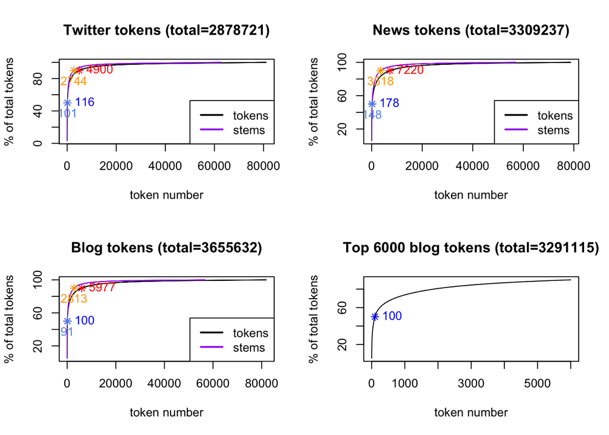

The first 200 or so tokens are enough to capture 50% of all word occurrences (shown is detail for “blog”, but the pattern is similar for the others). The blue and red points shown are the token numbers that account for 50 and 90% of all word occurrences respectively. About 8000 tokens would capture 90% of all tokens occurring.

Note however that we have sampled 10% of the available training data and that according to [Oxford](https://en.oxforddictionaries.com/explore/how-many-words-are-there-in-the-english-language) there are about 171,000 words in current use in English and this could rise up to some 750,000 if all senses of words are taken into account.

## 2-Ngrams

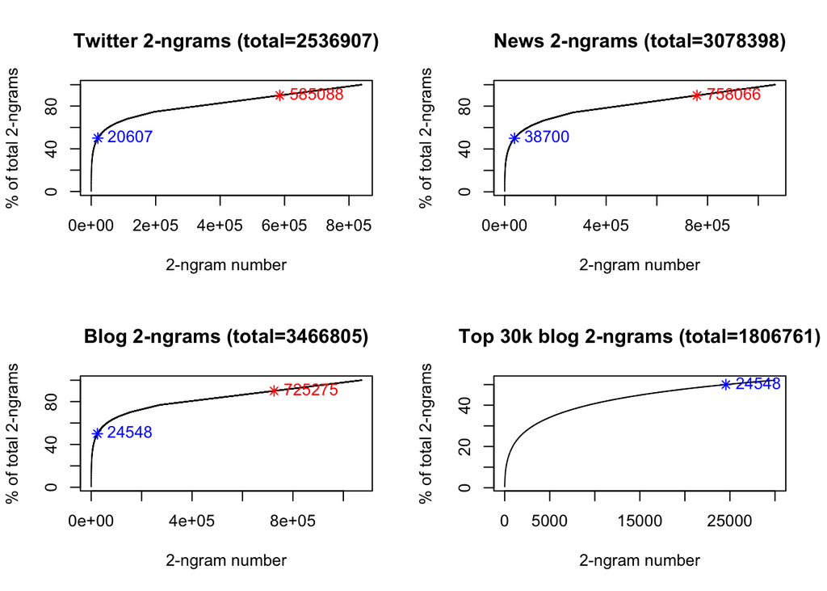

## 3-Ngrams

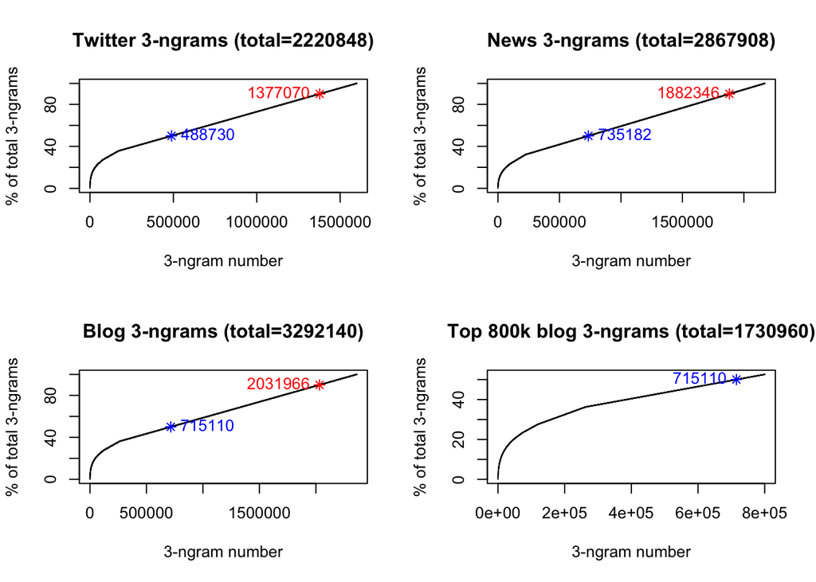

## 4-Ngrams

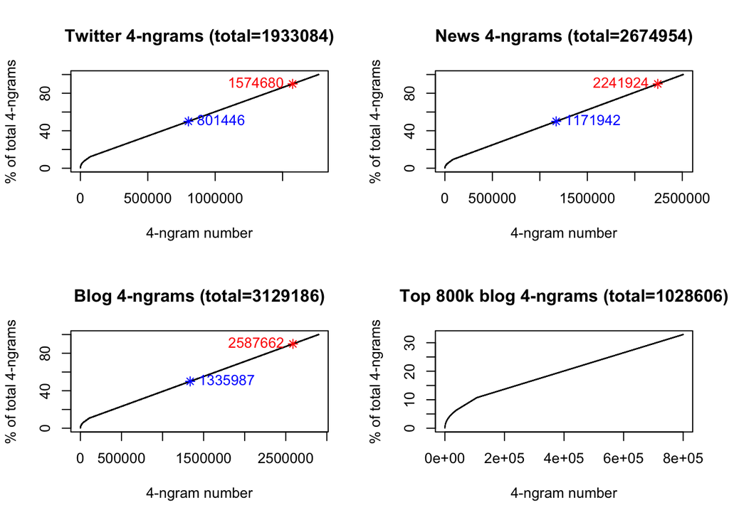

## Tokens and word stems in n-grams

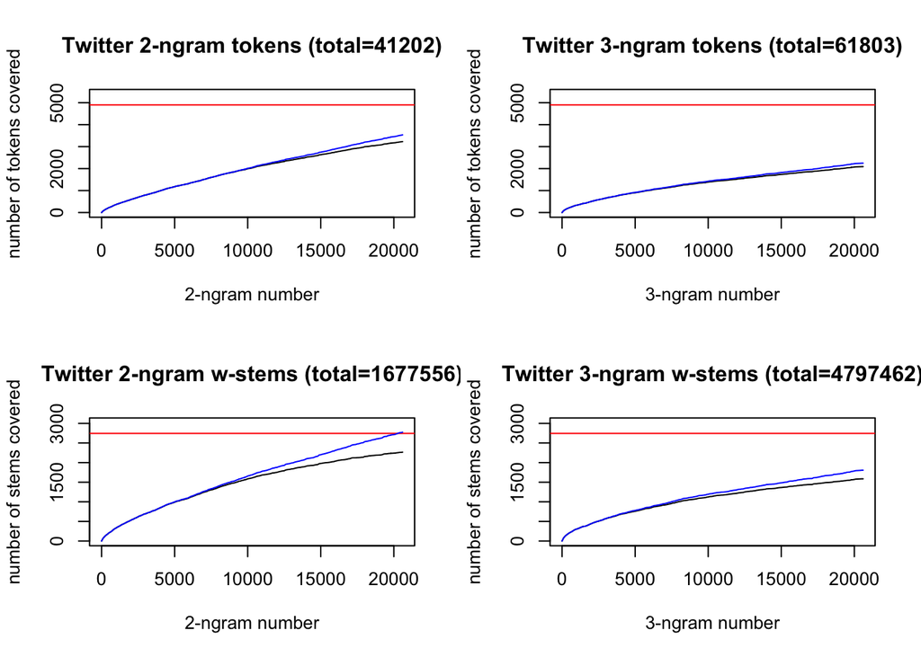

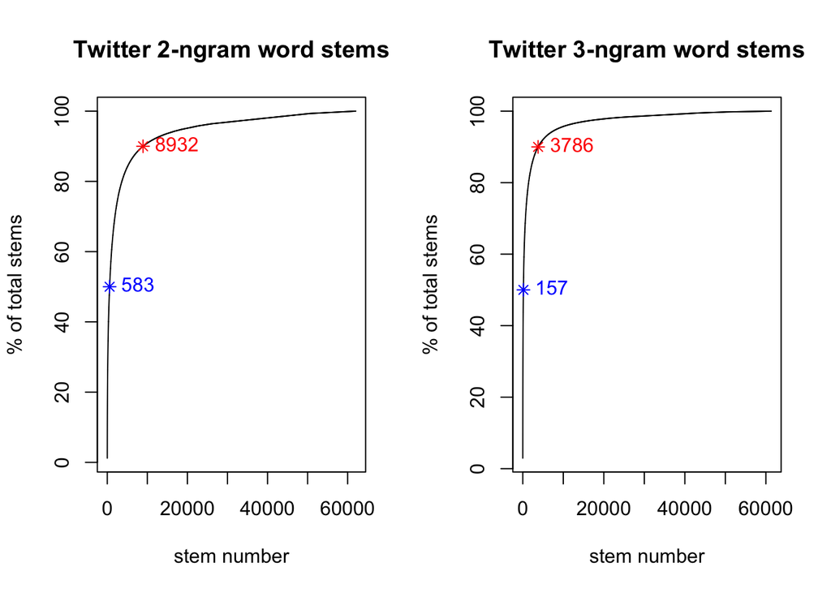

The red line is the number of tokens representing 90% of all words in the sample data. x-axis is the number of n-grams in a set, where the set of n-grams is taken from the ordered list of n-grams by frequency. Each y value is then the number of: **blue** the number of unique tokens used by the x-value number of n-grams, and **black** the number of tokens in the ngrams that are part of the 90% of all tokens used in the sample data as described before.

2-ngrams accounting for 50% of all 2-ngrams in the sample capture about 65% of the tokens accounting for 90% of the token usage in the sample. The 20,000 or so most frequent 3-ngrams cover only about 43% of the 90% of token usage.

## Plans for a next-word prediction model

Our model will use the information about frequencies above to create a Markov chains model for predicting the next word. We can store the conditional probabilities of a next word given the previous 1, 2 or 3 words in a matrix where the rows are identified by the “history” and the columns are the next word. Each cell in the matrix stores the probability = (observed frequency of the next word in the sample / total occurrences of the history leading up to this word).

Here we estimate the size of this Markov chain table for 50% and 90% coverage by creating an R object for each case (for the twitter sample data):

```r
library(matlab)
r50names <- c(tw_tbl$tw_tk[1:tw_50_idx],
              tw_2n_tbl$tw_2n[1:tw_2n_50_idx],
              tw_3n_tbl$tw_3n[1:tw_3n_50_idx])
c50names <- c(tw_tbl$tw_tk[1:tw_50_idx])
m50 <- matrix(data=zeros(length(r50names),length(c50names)),
                         nrow=length(r50names),ncol=length(c50names),
              dimnames=list(r50names,c50names)
                )
object.size(m50)
```

```
## 508307840 bytes
```

```r
remove("m50")
```

It can be clearly seen here that the memory requirement is significant. And this is even when we are considering only the number of 2 and 3-ngrams that cover 50% of uses. We will need to restrict the model to only n-grams with frequencies > 100 (this requires only about 2300 of the most frequent twitter n-grams):

```r
library(matlab)
rnames <- c(tw_tbl$tw_tk[1:tw_90_idx],
              tw_2n_tbl$tw_2n[1:2300],
              tw_3n_tbl$tw_3n[1:4600])
cnames <- c(tw_tbl$tw_tk[1:tw_50_idx])
m <- matrix(data=zeros(length(rnames),length(cnames)),
                         nrow=length(rnames),ncol=length(cnames),
              dimnames=list(rnames,cnames)
                )
object.size(m)
```

```
## 11674816 bytes
```

```r
remove("m")
```

We would need around 11 Mbytes to store the probabilities of next-word given history, where history is one of the 90% of 1-words used in the sample, or one of the 2-ngrams with frequency > 100 or a 3-ngram with frequency > 20 in the sample. But the next-word predicted would be just one of the 50% most commonly used.

Conclusion: some further reduction in memory requirements will come by using n-grams based on word-stems but clearly a good model needs more work.